# Home assignment

Anna Gladysheva

19 ноября 2018 г

# 1 Установка пакетов

```r
library(tidyverse) # манипуляции с данными
library(rio) # импорт разных форматов
#install.packages("skimr")
library(skimr) # описательные статистики
library(lattice)
#install.packages("DataExplorer")
library(DataExplorer)
library(tidyverse) # обработка данных, графики...
library(vcd) # мозаичные графики для качественных переменных
#library(ggalluvial) # потоковые ???? графики для качественных переменных
#install.packages("corrplot")
library(corrplot) # визуализация корреляций
#install.packages("latex2exp")
library(latex2exp) # формулы в подписях к графику

#devtools::install_github("thomasp85/patchwork")
library(patchwork) # удобное расположение графиков рядом

library(lmtest) # диагностика линейных моделей
library(sjstats) # удобные мелкие функции для работы с моделями
library(sjPlot) # ещё больше графиков
library(fmsb)
library(sandwich) # оценка Var для гетероскедастичности
#install.packages("stargazer")
library(stargazer) # красивые таблички в html, tex
library(texreg) # и снова красивые таблички в html, tex :)
#install.packages("estimatr")
library(estimatr) # модели с робастными ошибками
```

# 2 Импорт данных

Данные по стоимости квартир и различных их характеристик для двухкомнатных квартир, расположенных в ЗАО, ЮВАО и ЮАО Москвы в 2013 году. Источник данных - [ЦИАН](https://www.cian.ru/kupit/)

- totsp – общая площадь квартиры, кв.м.
- livesp – жилая площадь квартиры, кв.м.
- kitsp – площадь кухни, кв.м.
- dist – расстояние от центра в км.
- metrdist – расстояние до метро в минутах
- walk 1 – пешком от метро, 0 – на транспорте
- floors – Число этажей в доме
- Nfloor – Номер этажа на котором расположена квартира
- okrug: w – квартира в ЗАО se – квартира в ЮВАО s – квартира в ЮАО
- price_rub – цена квартиры в рублях
- price_m_rub – цена кв. м. в рублях
- zamkad – 1 – квартира за МКАД, 0 – нет

# 3 Описательный анализ данных

## 3.1 Описательные статистики

```
## Observations: 2,753
## Variables: 12
## $ totsp       <dbl> 51.7, 58.0, 58.0, 38.6, 53.0, 47.7, 47.1, 34.1, 44...
## $ livesp      <dbl> 30.0, 32.0, 32.0, 23.7, 30.6, 30.4, 30.3, 21.9, 28...
## $ kitsp       <dbl> 10.0, 11.0, 11.0, 6.3, 10.0, 7.0, 6.6, 6.5, 6.0, 6...
## $ dist        <dbl> 20.5, 19.5, 23.5, 14.5, 11.0, 14.5, 14.5, 9.0, 15....
## $ metrdist    <dbl> 24, 12, 26, 8, 4, 19, 17, 5, 9, 12, 9, 7, 6, 16, 8...
## $ walk        <dbl> 0, 0, 0, 0, 0, 0, 0, 0, 0, 0, 1, 0, 1, 0, 1, 0, 0,...
## $ floors      <dbl> 17, 19, 19, 14, 24, 12, 12, 9, 9, 9, 5, 14, 9, 12,...
## $ Nfloor      <dbl> 6, 6, 14, 10, 17, 2, 3, 2, 5, 5, 3, 10, 2, 3, 4, 1...
## $ price_rub   <dbl> 4032600, 5110000, 5110000, 5400000, 5450000, 57000...
## $ price_m_rub <dbl> 78000, 88103, 88103, 139896, 102830, 119497, 12314...
## $ zamkad      <dbl> 0, 0, 0, 0, 0, 0, 0, 0, 0, 0, 0, 0, 0, 0, 0, 0, 0,...
## $ okrug       <chr> "S", "S", "S", "S", "S", "S", "S", "S", "S", "S", ...
```

```
## Skim summary statistics
##  n obs: 2753
##  n variables: 12
##
## -- Variable type:character -----------------------------------------------------------------------------------------------------
##  variable missing complete    n min max empty n_unique
##     okrug       0     2753 2753   1   2     0        3
##
## -- Variable type:numeric -------------------------------------------------------------------------------------------------------
##     variable missing complete    n       mean         sd        p0
##         dist       0     2753 2753      11.35       3.75       2.5
##       floors       0     2753 2753      11.36       5.81       3
##        kitsp       0     2753 2753       8.9        3.02       4
##       livesp       0     2753 2753      32.02       5.9       17
##     metrdist       0     2753 2753       8.54       4          1
##       Nfloor       0     2753 2753       5.94       5.36       1
##  price_m_rub       0     2753 2753  174436.41   46312.83   69643
##    price_rub       0     2753 2753 9567339.58 4154606.74 3500000
##        totsp       0     2753 2753      53.98      12.07      33
##         walk       0     2753 2753       0.65       0.48       0
##       zamkad       0     2753 2753       0.06       0.24       0
##       p25       p50      p75     p100     hist
##       9        12       13.5     23.5 ▂▂▃▇▃▂▁▁
##       7        10       16       40   ▅▇▂▂▁▁▁▁
##       6.5       8.6     10       34   ▆▇▂▁▁▁▁▁
##      29        31       34       80   ▁▇▃▁▁▁▁▁
##       6         8       11       34   ▅▇▅▂▁▁▁▁
##       1         4        9       39   ▇▂▂▁▁▁▁▁
##  146154    163043   190000   548560   ▁▇▂▁▁▁▁▁
##   7e+06   8380000    1e+07    4e+07   ▇▇▂▁▁▁▁▁
##      45        52       58.5    110   ▂▇▆▂▁▁▁▁
##       0         1        1        1   ▅▁▁▁▁▁▁▇
##       0         0        0        1   ▇▁▁▁▁▁▁▁
```

В базе 12 переменных, 2753 налюдения.

Таблички пока ужасны, но я над этим работаю=)

## 3.2 Типы переменных

Изначально в базе 11 текстобых переменных (типа “dbl”), 1 текстовая (переменная okrug имеет тип “chr”). Однако для части переменных стоит перезадать тип и сделать их факторными. Это переменные *walk*, *zamkad* и *okrug*. Также исключим переменную и цену на всю квартиру (так как это вспомогательная перемнная) *price_rub*.

```
## # A tibble: 3 x 2
##   okrug     okr
##   <fct>   <dbl>
## 1 S     163428.
## 2 SE    156834.
## 3 W     199985.
```

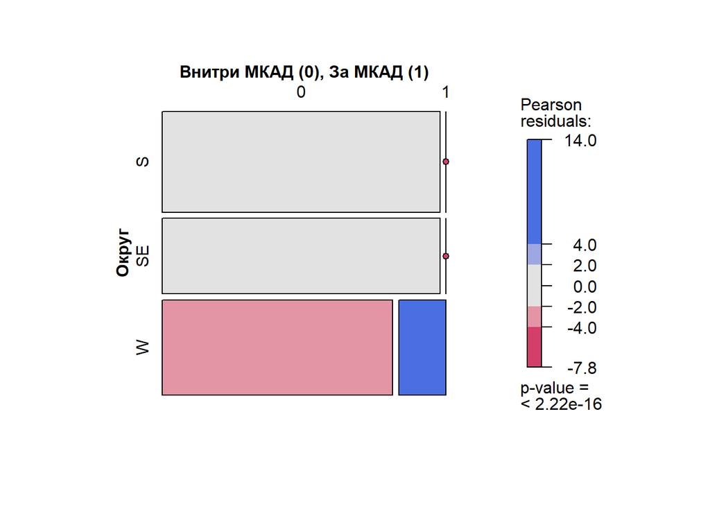

Срежняя цена за квадратный метр выше в Западном округе. При этот только в Западном округе есть картиры, находящиеся за МКАД.

## 3.3 Графический анализ

Изучим распределение наблюдений в выборке.

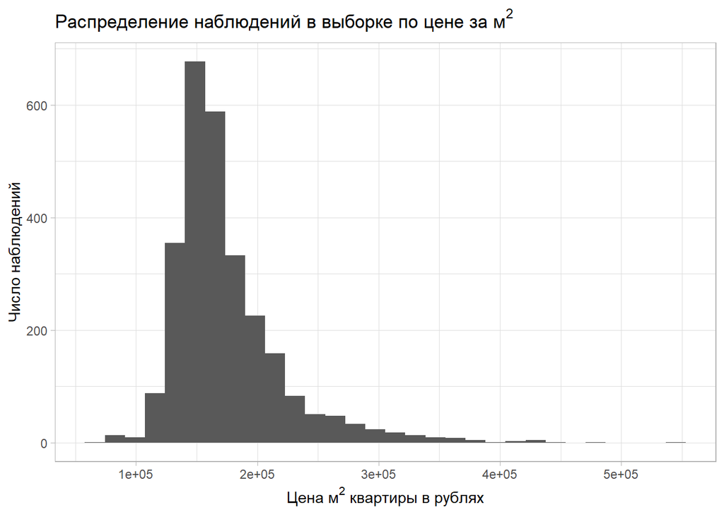

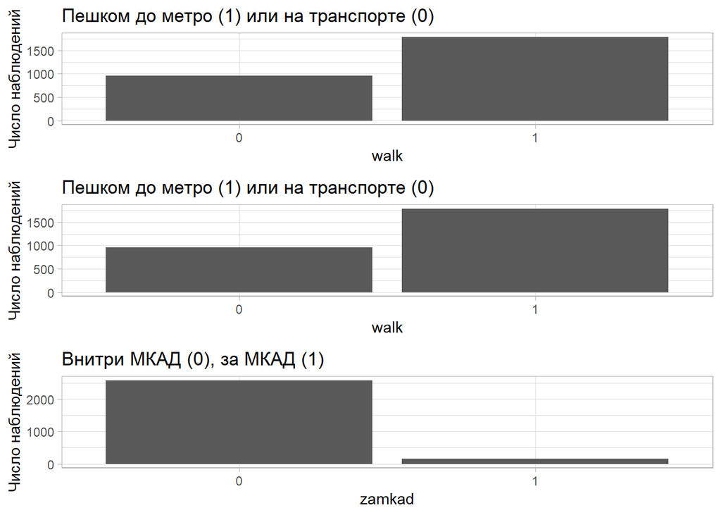

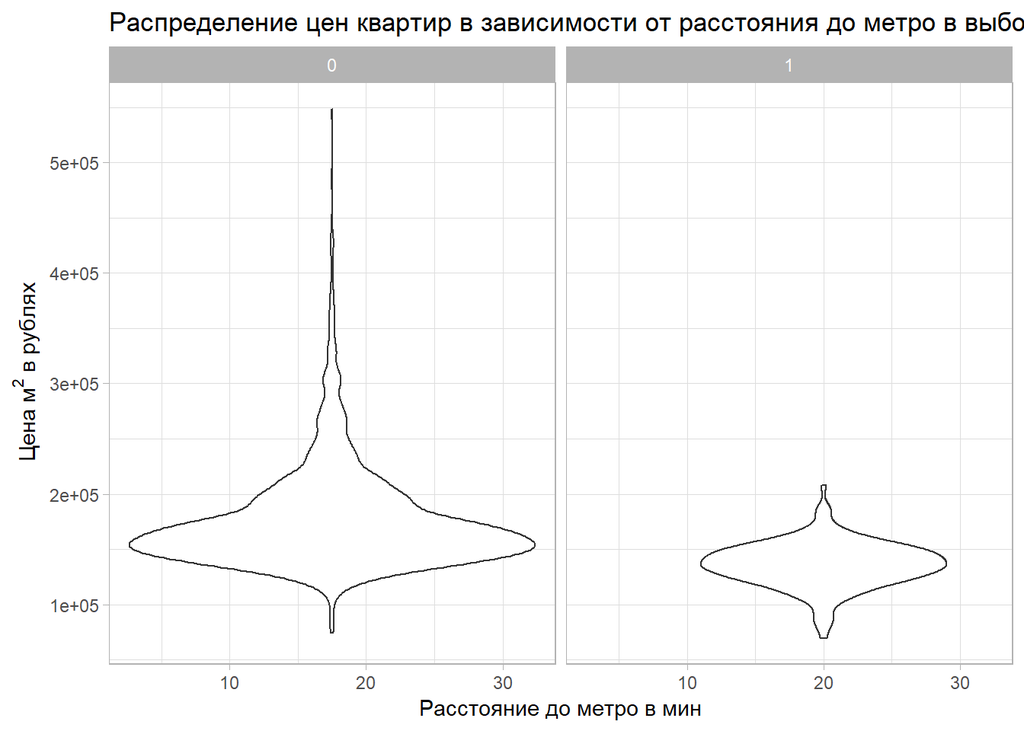

Изучим илнейную взаимосвязь исследуемых признаков, построив матрицу парных корреляций для количественных переменных. Исключим факторные переменные и построим матрицу, затем визуализируем её.

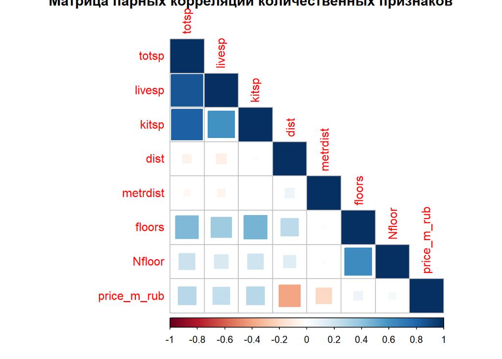

Цена за квадратный мер имеет самую сильную корреляцию с расстоянием до центра города *dist*, эта корреляция отрицательная. Также имеет место высокая положительная корреляция между характеристиками квартиры (например, общей площадью картиры, площадью кухни и жилой площадью).

Построим диаграмму рассеяния в координатах расстояния до центра города и цены за квадратный метр (предварительно приведя цену к тысячам рублей за квадратный метр), оценим зависимость и наложим её на график.

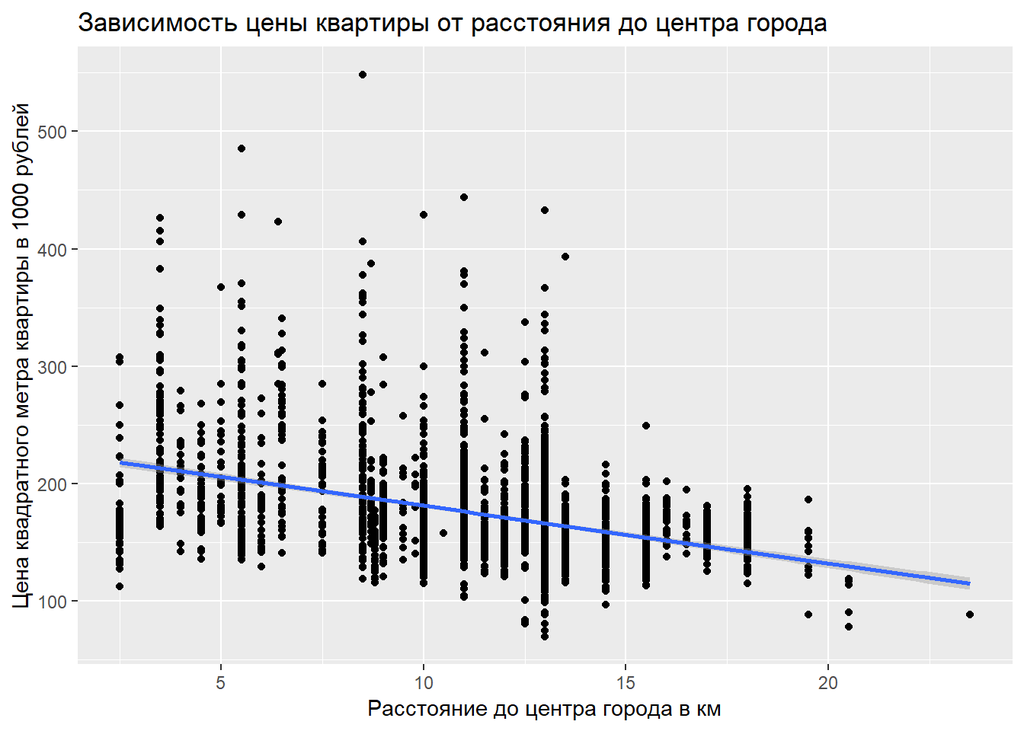

Далее с помощью диаграмм рассеяния изучим зависимость цены за квадратный метр от обзей площади квартиры, площади кухни и жилой площади.

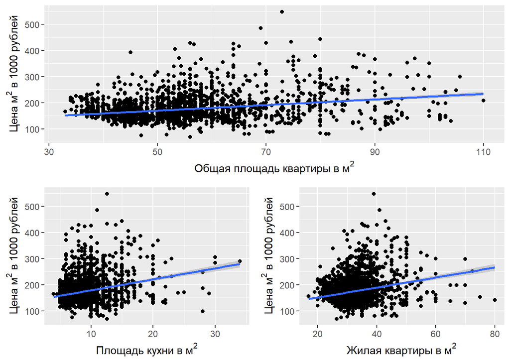

# 4 Модель линейной регрессии

Оценим линейную множественную регрессионную модель зависимости цены на квадратный метр квартиры от расстояния до центра, расстояния до метро, общей площади, жилой площади и пложади кухни, а также от факта расположения внутри или за МКАД. Рассмотрим отдельно доверительные интервала коэффициентов модели.

```
##
## Call:
## lm(formula = price_m_rub ~ dist + metrdist + totsp + kitsp +
##     livesp + zamkad, data = data_ag)
##
## Residuals:
##     Min      1Q  Median      3Q     Max
## -146713  -21357   -4420   15459  343055
##
## Coefficients:
##             Estimate Std. Error t value Pr(>|t|)
## (Intercept) 187203.5     5306.1  35.281  < 2e-16 ***
## dist         -4480.6      202.2 -22.163  < 2e-16 ***
## metrdist     -1237.4      209.3  -5.913 3.78e-09 ***
## totsp          241.1      179.0   1.347    0.178
## kitsp         3219.0      458.2   7.025 2.69e-12 ***
## livesp         272.4      264.8   1.028    0.304
## zamkad      -28941.6     3548.7  -8.156 5.22e-16 ***
## ---
## Signif. codes:  0 '***' 0.001 '**' 0.01 '*' 0.05 '.' 0.1 ' ' 1
##
## Residual standard error: 39320 on 2746 degrees of freedom
## Multiple R-squared:  0.2809, Adjusted R-squared:  0.2793
## F-statistic: 178.7 on 6 and 2746 DF,  p-value: < 2.2e-16
```

```
##                   2.5 %      97.5 %
## (Intercept) 176799.1603 197607.7864
## dist         -4876.9692  -4084.1463
## metrdist     -1647.7233   -827.0177
## totsp         -109.9034    592.1614
## kitsp         2320.5160   4117.4942
## livesp        -246.9437    791.6792
## zamkad      -35899.9416 -21983.3522
```

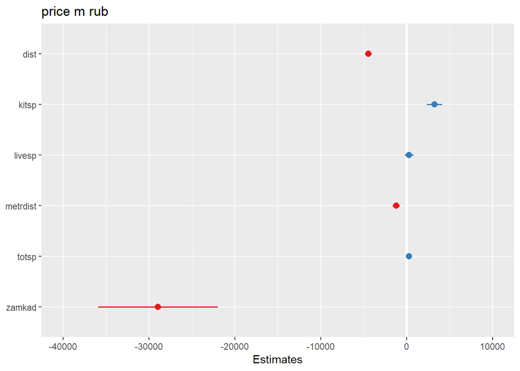

Регрессия значима, $R^2=0.28$. Значимы все коэффициенты, кроме двух - коэффициент при *totsp* и *livesp* статистически неотличимы от нуля.

Проверим, можем ли мы исключить эти регрессоры.

```
##
## Call:
## lm(formula = price_m_rub ~ dist + metrdist + kitsp + zamkad,
##     data = data_ag)
##
## Residuals:
##     Min      1Q  Median      3Q     Max
## -158099  -21476   -4415   14748  345342
##
## Coefficients:
##             Estimate Std. Error t value Pr(>|t|)
## (Intercept) 200365.2     3724.6  53.795  < 2e-16 ***
## dist         -4552.5      201.7 -22.574  < 2e-16 ***
## metrdist     -1288.8      209.3  -6.159 8.38e-10 ***
## kitsp         4320.4      250.3  17.259  < 2e-16 ***
## zamkad      -28425.7     3553.4  -8.000 1.82e-15 ***
## ---
## Signif. codes:  0 '***' 0.001 '**' 0.01 '*' 0.05 '.' 0.1 ' ' 1
##
## Residual standard error: 39400 on 2748 degrees of freedom
## Multiple R-squared:  0.2772, Adjusted R-squared:  0.2762
## F-statistic: 263.5 on 4 and 2748 DF,  p-value: < 2.2e-16
```

```
## Wald test
##
## Model 1: price_m_rub ~ dist + metrdist + totsp + kitsp + livesp + zamkad
## Model 2: price_m_rub ~ dist + metrdist + kitsp + zamkad
##   Res.Df Df      F    Pr(>F)
## 1   2746
## 2   2748 -2 6.9594 0.0009665 ***
## ---
## Signif. codes:  0 '***' 0.001 '**' 0.01 '*' 0.05 '.' 0.1 ' ' 1
```

Два упомянутых выше регрессора совместно значимы, исключить их из модели не можем. Возможная причина незначимости - мультиколлинеарность.

```
## [1] 1.390532
```

Другое возможное свойство модели - гетероскедастичность. Переоченим модель с учетом этого.

```
##
## Call:
## lm_robust(formula = price_m_rub ~ dist + metrdist + totsp + kitsp +
##     livesp + zamkad, data = data_ag)
##
## Standard error type:  HC2
##
## Coefficients:
##             Estimate Std. Error  t value   Pr(>|t|) CI Lower CI Upper   DF
## (Intercept) 187203.5     6777.6  27.6209 2.124e-148 173913.8 200493.2 2746
## dist         -4480.6      223.6 -20.0353  1.879e-83  -4919.1  -4042.1 2746
## metrdist     -1237.4      187.6  -6.5960  5.047e-11  -1605.2   -869.5 2746
## totsp          241.1      236.3   1.0206  3.075e-01   -222.1    704.4 2746
## kitsp         3219.0      585.2   5.5010  4.125e-08   2071.6   4366.4 2746
## livesp         272.4      386.2   0.7053  4.807e-01   -484.9   1029.6 2746
## zamkad      -28941.6     2586.9 -11.1877  1.913e-28 -34014.2 -23869.1 2746
##
## Multiple R-squared:  0.2809 ,    Adjusted R-squared:  0.2793
## F-statistic: 137.6 on 6 and 2746 DF,  p-value: < 2.2e-16
```

Представим результаты трё оценённых моделей в единой таблице.

Statistical models

|  | **Model 1** | **Model 2** | **Model 3** |  |
| --- | --- | --- | --- | --- |
| (Intercept) | 187203.47*** | 200365.18*** | 187203.47*** |  |
|  | (5306.08) | (3724.60) | (6777.61) |  |
| dist | -4480.56*** | -4552.48*** | -4480.56*** |  |
|  | (202.17) | (201.67) | (223.63) |  |
| metrdist | -1237.37*** | -1288.84*** | -1237.37*** |  |
|  | (209.28) | (209.26) | (187.59) |  |
| totsp | 241.13 |  | 241.13 |  |
|  | (179.02) |  | (236.26) |  |
| kitsp | 3219.01*** | 4320.44*** | 3219.01*** |  |
|  | (458.22) | (250.33) | (585.17) |  |
| livesp | 272.37 |  | 272.37 |  |
|  | (264.84) |  | (386.17) |  |
| zamkad | -28941.65*** | -28425.68*** | -28941.65*** |  |
|  | (3548.65) | (3553.39) | (2586.92) |  |
| R<sup>2</sup> | 0.28 | 0.28 | 0.28 |  |
| Adj. R<sup>2</sup> | 0.28 | 0.28 | 0.28 |  |
| Num. obs. | 2753 | 2753 | 2753 |  |
| RMSE | 39317.40 | 39402.58 | 39317.40 |  |
| ***p < 0.001, **p < 0.01, *p < 0.05 |  |  |  |  |

*На этом пока всё=) С оформлением беда, но, надеюсь, я с этим разберусь*

**Огромное спасибо за курс!**